# MBA Student Portfolio

# Divya Prabha Palani

MBA Candidate | University Canada West  
Download My Resume

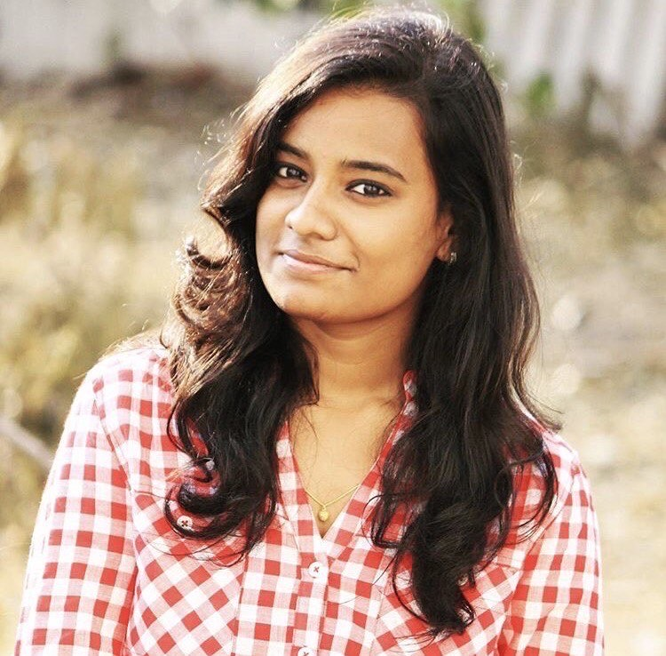

## About Me

I am an MBA student at University Canada West with a background in banking, finance, and customer service. With five years of professional experience in backend banking operations and customer service at NatWest Group and Accenture Solutions, I bring a deep understanding of financial processes, risk mitigation, and compliance. I am certified in data analytics and passionate about applying technology and strategy to improve customer experience and operational excellence.

## Education

- **Master of Business Administration (MBA)**  
  University Canada West, Vancouver, Canada *(Present)*
- **Bachelor of Commerce in Bank Management**  
  Madras University, Chennai, India

## Experience

- **Customer Service & Operations Senior Analyst**  
  *NatWest Group* | Chennai, India | June 2019 – April 2024  
  Oversaw corporate banking operations, mandate processing, billing, compliance, and data accuracy.
- **Customer Service & Operations Analyst (Accounts Payable)**  
  *Accenture Solutions India Pvt Ltd* | June 2018 – June 2019  
  Managed invoice processing, audit support, and vendor communications for high-volume accounts payable.
- **Food Service Worker (Part-time)**  
  *Saravana Bhavan, Delta, Canada* | July 2024 – Present  
  Provided efficient food service and customer support in a fast-paced restaurant setting.

## Key Skills

- Customer Service & Relationship Management
- Banking Operations | AML & KYC Compliance
- Data Analytics (Python, MySQL)
- Financial Reporting & Billing Operations
- Process Improvement & Risk Mitigation
- CRM Application & Record Management
- Team Collaboration & Communication

## Certifications

- **Data Analytics Certification** – Great Learning, 2023
- **Python (Basics)** – HackerRank, 2023

## Projects

**Streamlining Corporate Billing Operations** – *NatWest Group*  
Role: Senior Analyst  
- Improved billing accuracy and efficiency for corporate clients. - Reduced billing cycle time by 20% and billing errors by 15%. - Enhanced customer satisfaction scores by 10%. - Successfully passed internal and external audits with no major findings.

## Contact

📧 divyaprabha241026@gmail.com  
📞 +1 (236) 862-3079  
🌐 [LinkedIn](https://www.linkedin.com/in/divyaprabha-palani)